# Clase Estadística Descriptiva

Laboratorio de Datos

Martin Menalled

2023-02-08

Consigna inicial:

```r
datos <- read.csv("ar_properties.csv")
filtro_barrios <- is.element(datos$l3,"Boedo") |
                              is.element(datos$l3,"Colegiales") |
                              is.element(datos$l3,"Centro / Microcentro") |
                              is.element(datos$l3,"Mataderos") |
                              is.element(datos$l3,"Puerto Madero")
filtro_localidad <- is.element(datos$l2,"Capital Federal")
filtro_pais <- is.element(datos$l1,"Argentina")
filtros <- filtro_pais & filtro_localidad & filtro_barrios

datos_filtrados <- datos[filtros,]
datos_filtrados
```

|  | id | ad_type | start_date | end_date | created_on | lat | lon | l1 | l2 | l3 | l4 | l5 | l6 | rooms | bedrooms | bathrooms | surface_total | surface_covered | price | currency | price_period | title | property_type | operation_type |
| --- | --- | --- | --- | --- | --- | --- | --- | --- | --- | --- | --- | --- | --- | --- | --- | --- | --- | --- | --- | --- | --- | --- | --- | --- |
| 2 | kMxcmAS8NvrynGBVbMOEaQ== | Propiedad | 2019-04-14 | 2019-04-16 | 2019-04-14 | -34.63181 | -58.42060 | Argentina | Capital Federal | Boedo | NA | NA | NA | NA | NA | NA | NA | NA | 0 | NA | Mensual | PH - Boedo | PH | Venta |
| 49 | WP1Nq9/ESbQYKMYdQryL1A== | Propiedad | 2019-04-14 | 2019-04-29 | 2019-04-14 | -34.57827 | -58.46255 | Argentina | Capital Federal | Colegiales | NA | NA | NA | NA | NA | 5 | 900 | 900 | 0 | NA | Mensual | Local de 1 ambiente en Alquiler en Colegiales | Local comercial | Alquiler |
| 50 | shKAu1QR+SzX487bMydFIA== | Propiedad | 2019-04-14 | 2019-04-29 | 2019-04-14 | -34.57555 | -58.43981 | Argentina | Capital Federal | Colegiales | NA | NA | NA | NA | NA | 5 | 2753 | 2753 | 0 | NA | Mensual | Local de 1 ambiente en Alquiler en Colegiales | Local comercial | Alquiler |
| 51 | NaxxEMzh1IfoBoO8ztlhWA== | Propiedad | 2019-04-14 | 2019-04-29 | 2019-04-14 | -34.57533 | -58.46353 | Argentina | Capital Federal | Colegiales | NA | NA | NA | NA | NA | 5 | 1350 | 1350 | 0 | NA | Mensual | Local de 1 ambiente en Alquiler en Colegiales | Local comercial | Alquiler |
| 91 | 3bEoPj/d6gzaFqFDmsWaWg== | Propiedad | 2019-04-14 | 2019-07-10 | 2019-04-14 | -34.57739 | -58.45630 | Argentina | Capital Federal | Colegiales | NA | NA | NA | NA | NA | 1 | 50 | 50 | 15000 | ARS | Mensual | PH EN ALQUILER | PH | Alquiler |
| 121 | AWjEkuPykUjCnrZM09CzTg== | Propiedad | 2019-04-14 | 2019-04-29 | 2019-04-14 | -34.61703 | -58.37037 | Argentina | Capital Federal | Centro / Microcentro | NA | NA | NA | NA | NA | 1 | 55 | 55 | 12800 | ARS | Mensual | Oficina de 1 ambiente en Alquiler en Centro | Oficina | Alquiler |
| 145 | RDxlEgRfBvzEw7l5xO+ltg== | Propiedad | 2019-04-14 | 2019-07-03 | 2019-04-14 | -34.58837 | -58.45000 | Argentina | Capital Federal | Colegiales | NA | NA | NA | NA | NA | 1 | 27 | 24 | 10000 | ARS | NA | Santos Dumont 4000 1° - $ 10.000 - Departamento Alquiler | Departamento | Alquiler |
| 203 | t1xP7b2Zhvs6FNxUyMXh0Q== | Propiedad | 2019-04-14 | 2019-06-23 | 2019-04-14 | -34.60956 | -58.36267 | Argentina | Capital Federal | Puerto Madero | NA | NA | NA | 2 | 1 | 2 | 73 | 63 | 50000 | ARS | NA | Excelente vista. Dos ambientes. Cochera. Amenities. | Departamento | Alquiler |
| 205 | cDskd3hP8rb3yY+3Rxi9YQ== | Propiedad | 2019-04-14 | 2019-06-27 | 2019-04-14 | -34.57736 | -58.45638 | Argentina | Capital Federal | Colegiales | NA | NA | NA | 3 | 2 | 2 | 105 | 65 | 20000 | ARS | Mensual | PH EN ALQUILER | PH | Alquiler |
| 220 | 2i8ibVFhTgRzJvgLJ8lTMg== | Propiedad | 2019-04-14 | 2019-06-08 | 2019-04-14 | -34.58243 | -58.45207 | Argentina | Capital Federal | Colegiales | NA | NA | NA | 3 | 2 | 1 | 62 | 54 | 19000 | ARS | Mensual | DEPARTAMENTO EN ALQUILER | Departamento | Alquiler |

[output cut: 990 more lines]

```r
NA
```

### Tamaño de las propiedades

1. A partir de los datos,¿existen propiedades con datos faltantes en términos de superficie y número de ambientes?

Propiedades con superficie total faltante:

```r
nrow(datos_filtrados[is.na(datos_filtrados$surface_total),])
```

```
[1] 722
```

Propiedades con superficie cubierta faltante:

```r
nrow(datos_filtrados[is.na(datos_filtrados$surface_covered),])
```

```
[1] 931
```

Propiedades con número de ambientes faltante:

```r
nrow(datos_filtrados[is.na(datos_filtrados$rooms),])
```

```
[1] 3088
```

Propiedades con número de ambientes y superficie faltante:

```r
nrow((datos_filtrados[is.na(datos_filtrados$rooms)&is.na(datos_filtrados$surface_total),]))
```

```
[1] 313
```

2. Visualizar la superficie y número de habitaciones en cada barrio. Sugerencia: Construir histogramas para las superficies, y barplots para el número de habitaciones

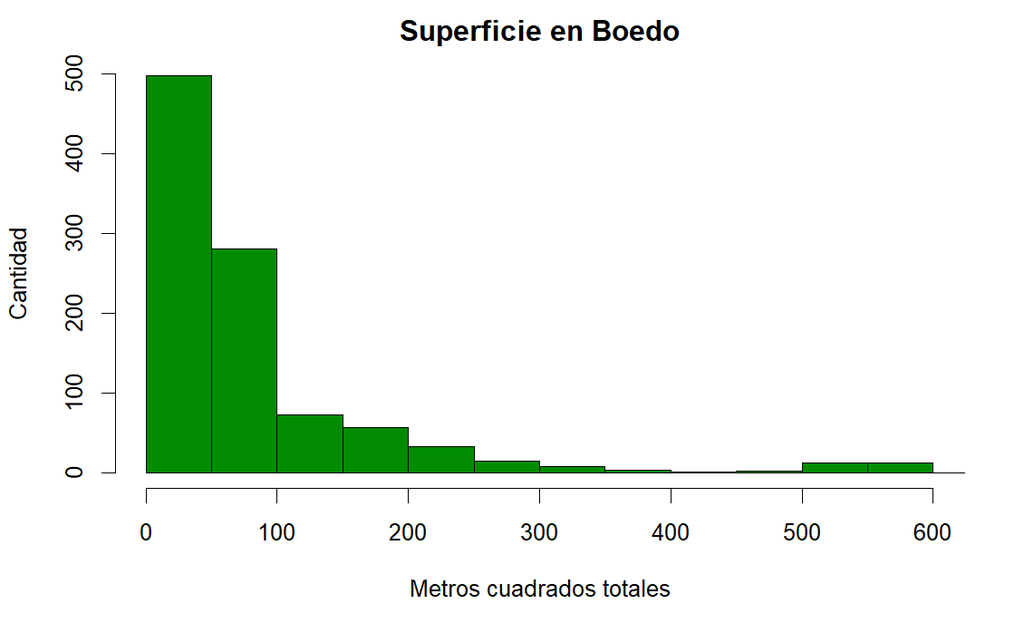

```r
hist(datos_filtrados$surface_covered[datos_filtrados$l3=="Boedo"],
     col="green4", main = "Superficie en Boedo", right=TRUE,
     breaks = 50, xlim=c(1,600), xlab = "Metros cuadrados totales",
     ylab="Cantidad")
```

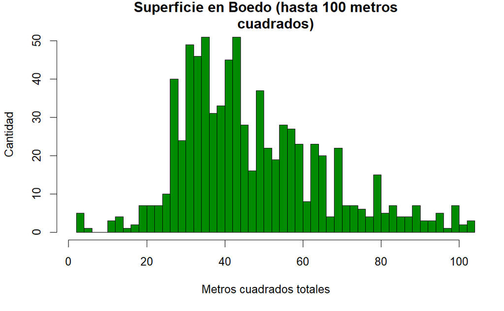

```r
hist(datos_filtrados$surface_covered[datos_filtrados$l3=="Boedo"],
     col="green4", main = "Superficie en Boedo (hasta 100 metros
     cuadrados)", right=TRUE, breaks = 1000, xlim=c(1,100), xlab =
    "Metros cuadrados totales",ylab="Cantidad")
```

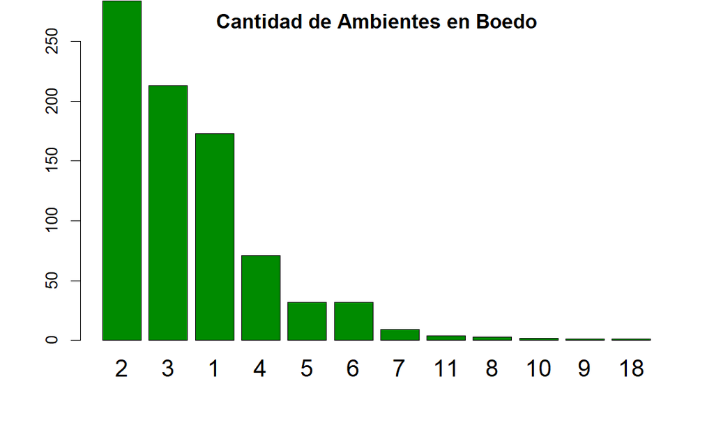

```r
barplot(sort(table(datos_filtrados$rooms[datos_filtrados$l3==
            "Boedo"]),decreasing=TRUE), cex.names=1.4,
            col="green4",main="Cantidad de Ambientes en Boedo", ylim=c(0,250))
```

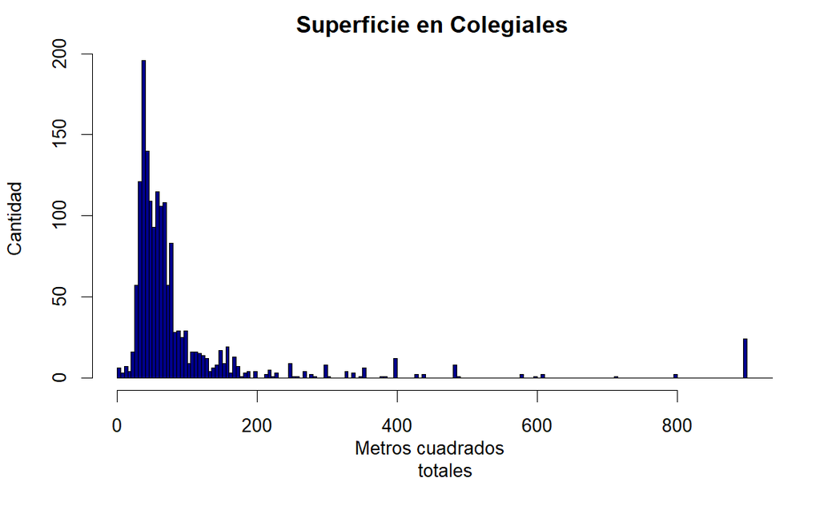

```r
hist(datos_filtrados$surface_covered[datos_filtrados$l3==
                                       "Colegiales"],col="blue4", main = "Superficie en Colegiales", right=TRUE,
     breaks = 750, xlim=c(1,900), xlab = "Metros cuadrados
     totales",ylab="Cantidad")
```